# practice-with-plots

D Blana

17/09/2021

## Load packages

```r
library(tidyverse)
# Install the 'viridis' package with a specified CRAN mirror
install.packages("viridis", repos = "https://cran.rstudio.com/")
```

```r
install.packages("plotly", repos = "https://cran.rstudio.com/")
library(viridis)   # nice colour scheme
library(plotly)    # interactive visualisations
```

## Read in the data

```r
admission_data <- read_csv("alcohol_related_admissions.csv")
glimpse(admission_data)
```

```
## Rows: 12,790
## Columns: 5
## $ area_name          <chr> "Culter", "Cults, Bieldside & Milltimber West", "Cu…
## $ area_code          <chr> "S02001236", "S02001237", "S02001238", "S02001239",…
## $ year               <dbl> 2010, 2010, 2010, 2010, 2010, 2010, 2010, 2010, 201…
## $ alcohol_admissions <dbl> 475.18, 732.32, 372.46, 1306.45, 359.21, 416.62, 23…
## $ health_board       <chr> "Grampian", "Grampian", "Grampian", "Grampian", "Gr…
```

## Median admissions

Here we calculate the median admissions for each health board and each year, using “group_by”.

```r
median_admissions <- admission_data %>%
  group_by(year, health_board) %>%
  summarise(median_admissions = median(alcohol_admissions))
head(median_admissions)
```

```
## # A tibble: 6 × 3
## # Groups:   year [1]
##    year health_board          median_admissions
##   <dbl> <chr>                             <dbl>
## 1  2010 Ayrshire and Arran                 917.
## 2  2010 Borders                            608.
## 3  2010 Dumfries and Galloway              475.
## 4  2010 Fife                               537.
## 5  2010 Forth Valley                       384.
## 6  2010 Grampian                           453.
```

## Simple bar chart

You can read a lot more about bar plots here: https://www.r-graph-gallery.com/barplot.html

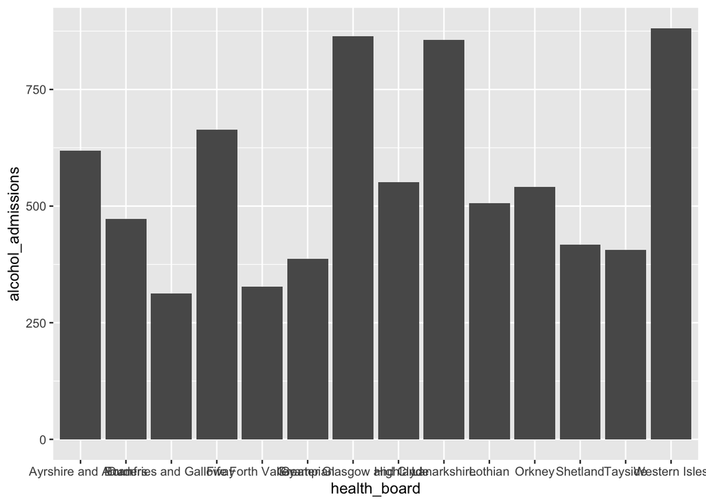

```r
median_admissions %>%
  filter(year == 2019) %>%
  rename(alcohol_admissions = median_admissions) %>%
  ggplot(aes(x=health_board, y=alcohol_admissions)) +
  geom_bar(stat = "identity")
```

Instead of wrapping the names, let’s make the graph horizontal instead using “coord_flip”. Also add labels and a title.

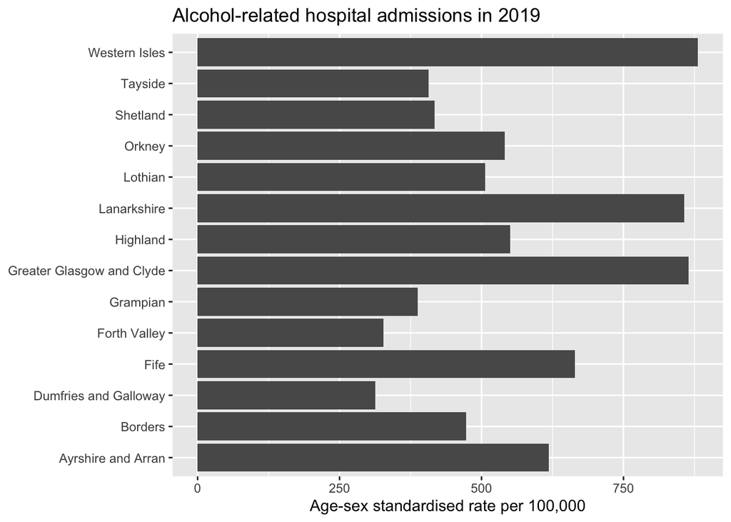

```r
median_admissions %>%
  filter(year == 2019) %>%
  rename(alcohol_admissions = median_admissions) %>%
  ggplot(aes(x=health_board, y=alcohol_admissions)) +
  geom_bar(stat = "identity") +
  coord_flip() +
  xlab(NULL) +
  ylab("Age-sex standardised rate per 100,000") +
  ggtitle("Alcohol-related hospital admissions in 2019")
```

Let’s also reorder them by size.

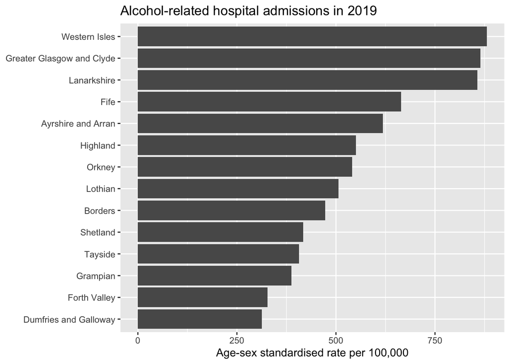

```r
median_admissions %>%
  filter(year == 2019) %>%
  rename(alcohol_admissions = median_admissions) %>%
  ggplot(aes(x=reorder(health_board,alcohol_admissions), y=alcohol_admissions)) +
  geom_bar(stat = "identity") +
  coord_flip() +
  xlab(NULL) +
  ylab("Age-sex standardised rate per 100,000") +
  ggtitle("Alcohol-related hospital admissions in 2019")
```

Exercise 1: Could you make Grampian stand out by giving it a different colour?

Add your code here!

Let’s make a lollipop graph instead.(https://www.r-graph-gallery.com/lollipop-plot.html)

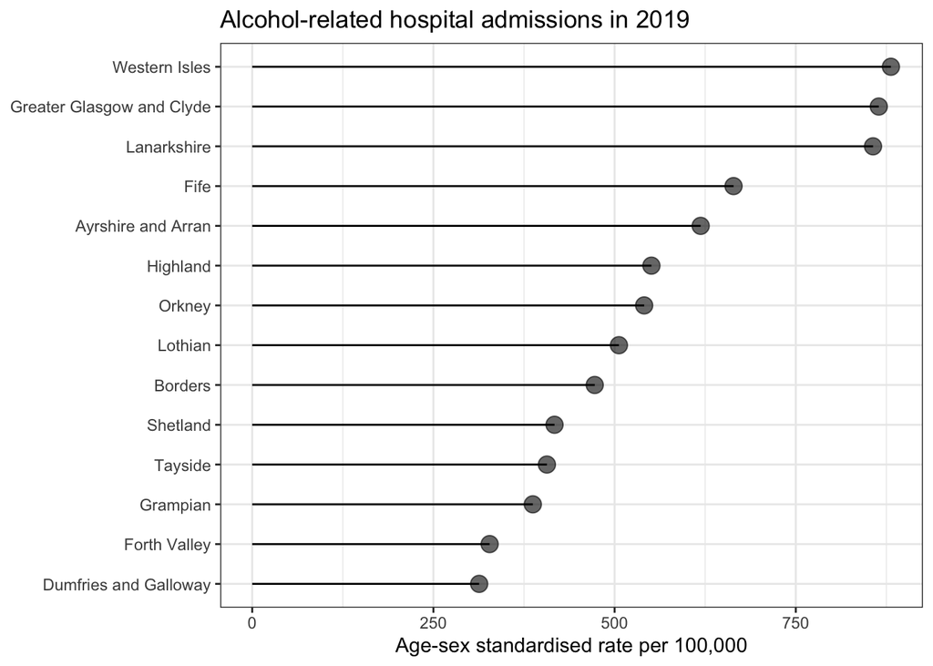

```r
median_admissions %>%
  filter(year == 2019) %>%
  rename(alcohol_admissions = median_admissions) %>%
  ggplot(aes(x=reorder(health_board,alcohol_admissions),
             y=alcohol_admissions)) +
  geom_segment(aes(xend=health_board, y=0, yend=alcohol_admissions)) +
  geom_point(size=4, alpha=0.6) +
  coord_flip() +
  xlab(NULL) +
  ylab("Age-sex standardised rate per 100,000") +
  ggtitle("Alcohol-related hospital admissions in 2019") +
  theme_bw()
```

Bar chart with two groups, for years 2010 and 2019

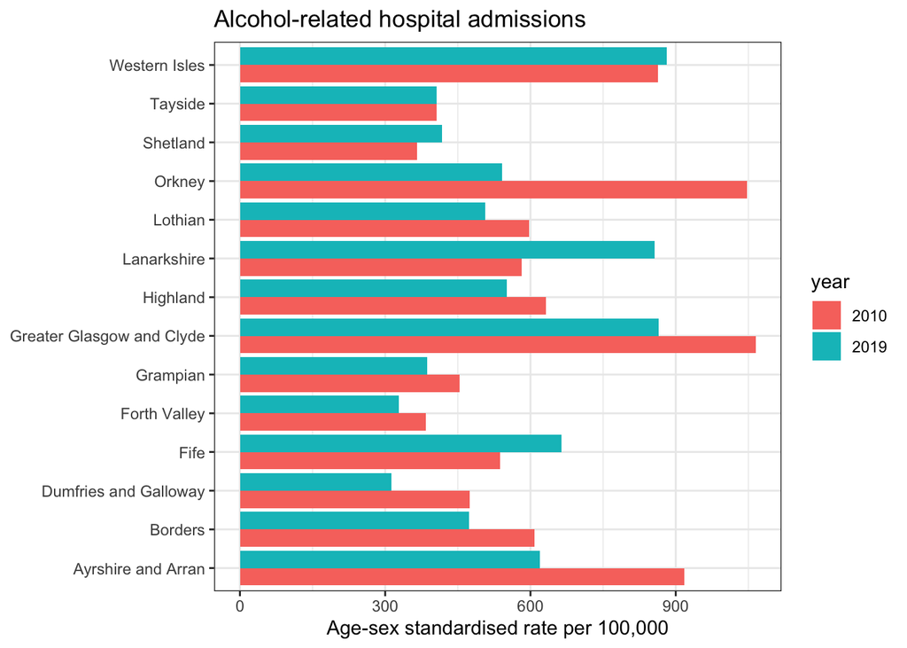

```r
median_admissions %>%
  filter(year %in% c(2010, 2019)) %>%   # only select these two years
  mutate(year = as.factor(year)) %>%          # convert years to categories ("factors")
  rename(alcohol_admissions = median_admissions) %>%
  ggplot(aes(x=health_board,
         y=alcohol_admissions,
         fill = year)) +
  geom_bar(position="dodge", stat = "identity") +  # without "dodge", we get a stacked bar chart
  coord_flip() +
  xlab(NULL) +
  ylab("Age-sex standardised rate per 100,000") +
  ggtitle("Alcohol-related hospital admissions") +
  theme_bw()
```

Exercise 2: Now try making a bar chart with three groups three years 2010, 2015 and 2019. Could you also improve the colours by using a different colour scheme?

(Hint: viridis includes a few different scales, which you can set using the “option” parameter in scale_fill_viridis, run ?scale_fill_viridis to see all options.You may also want to add a “begin” or “end” parameter, to make sure the lightest colour is not so light it’s not visible against the white background.)

Add your code here!

## Is there a relationship between alcohol-related hospital admissions and deprivation?

Let’s load the second dataset, “simd20_2019.csv”. This contains population estimates for each SIMD decile per health board in Scotland for 2019. It came from here: https://www.nrscotland.gov.uk/statistics-and-data/statistics/statistics-by-theme/population/population-estimates/2011-based-special-area-population-estimates/population-estimates-by-simd-2016

```r
deprivation_data <- read_csv("simd20_2019.csv")
glimpse(deprivation_data)
```

```
## Rows: 140
## Columns: 3
## $ `NHS health board` <chr> "Ayrshire and Arran", "Ayrshire and Arran", "Ayrshi…
## $ `SIMD decile`      <dbl> 1, 2, 3, 4, 5, 6, 7, 8, 9, 10, 1, 2, 3, 4, 5, 6, 7,…
## $ Population         <dbl> 49255, 62348, 35980, 44823, 44124, 24995, 29118, 26…
```

Let’s calculate the percent of the population in the most deprived areas (SIMD deciles 1-3) in each health board.

In the code below, we use first mutate & sum and then summarise & sum to calculate the sum of a column. The difference is that mutate adds a column to the existing dataframe, while summarise creates a new aggregate dataframe. Read more about this here: https://argoshare.is.ed.ac.uk/healthyr_book/summarise-vs-mutate.html

```r
# Calculate total population per health board, and population per SIMD decile, then divide to get the percent of the population at each SIMD decile

deprivation_data <- deprivation_data %>%
  group_by(`NHS health board`) %>%
  mutate(Total_population = sum(Population),
         Percent_population = Population/Total_population) %>%   # here we are adding new columns to the original dataframe
  ungroup()

# We can now keep SIMD = 1-3

deprived_ratio <- deprivation_data %>%
  filter(`SIMD decile` <= 3) %>%
  group_by(`NHS health board`) %>%
  summarise(percent_deprived = sum(Percent_population))  # here we are creating a new "summary" dataframe
```

Exercise 3: Link this dataset to median_admissions for 2019. (Remember to only keep the median alcohol admission data for the year 2019.)

Add your code here!

Exercise 4: Now create a scatterplot looking at the relationship between percent deprived and alcohol-related hospital admissions.

Add your code here!

Possible improvements:

1. Add text (https://ggplot2.tidyverse.org/reference/geom_text.html)
2. Make your visualisation interactive
3. Turn it into a bubble plot, using the total population of each health board for the circle size (https://www.r-graph-gallery.com/320-the-basis-of-bubble-plot.html). You will need to add the total population of each health board to the dataframe.